# Titanic

Angel Mak

July 4, 2015

# Overview

Goal :  
Predict whether Titanic passenger survived(1) or not(0)

Expected accuracy:  
“Know that a score of 0.79 - 0.81 is doing well on this challenge, and 0.81-0.82 is really going beyond the basic models!” - https://www.kaggle.com/c/titanic/details/getting-started-with-random-forests

“most people above 0.85 are almost definitely cheating” https://www.kaggle.com/c/titanic/forums/t/4894/what-accuracy-should-i-be-aiming-for

Kaggle competitle homepage:  
https://www.kaggle.com/c/titanic

Data cleaning was done based on this tutorial:  
https://github.com/wehrley/wehrley.github.io/blob/master/SOUPTONUTS.md

# Import train and test data

```r
library(caret)
library(gdata)
library(Amelia) # for missingness plot
library(Hmisc) # bystats
set.seed(333)

train.raw <- read.csv("/Users/angelmak/Dropbox/Kaggle/Titanic/train.csv",as.is=T,na.strings=c("NA",""))
test.raw <- read.csv("/Users/angelmak/Dropbox/Kaggle/Titanic/test.csv",as.is=T,na.strings=c("NA",""))
```

# Data formatting

What the data originally look like

```r
head(train.raw)
```

```
##   PassengerId Survived Pclass
## 1           1        0      3
## 2           2        1      1
## 3           3        1      3
## 4           4        1      1
## 5           5        0      3
## 6           6        0      3
##                                                  Name    Sex Age SibSp
## 1                             Braund, Mr. Owen Harris   male  22     1
## 2 Cumings, Mrs. John Bradley (Florence Briggs Thayer) female  38     1
## 3                              Heikkinen, Miss. Laina female  26     0
## 4        Futrelle, Mrs. Jacques Heath (Lily May Peel) female  35     1
## 5                            Allen, Mr. William Henry   male  35     0
## 6                                    Moran, Mr. James   male  NA     0
##   Parch           Ticket    Fare Cabin Embarked
## 1     0        A/5 21171  7.2500  <NA>        S
## 2     0         PC 17599 71.2833   C85        C
## 3     0 STON/O2. 3101282  7.9250  <NA>        S
## 4     0           113803 53.1000  C123        S
## 5     0           373450  8.0500  <NA>        S
## 6     0           330877  8.4583  <NA>        Q
```

```r
summary(train.raw)
```

```
##   PassengerId       Survived          Pclass          Name
##  Min.   :  1.0   Min.   :0.0000   Min.   :1.000   Length:891
##  1st Qu.:223.5   1st Qu.:0.0000   1st Qu.:2.000   Class :character
##  Median :446.0   Median :0.0000   Median :3.000   Mode  :character
##  Mean   :446.0   Mean   :0.3838   Mean   :2.309
##  3rd Qu.:668.5   3rd Qu.:1.0000   3rd Qu.:3.000
##  Max.   :891.0   Max.   :1.0000   Max.   :3.000
##
##      Sex                 Age            SibSp           Parch
##  Length:891         Min.   : 0.42   Min.   :0.000   Min.   :0.0000
##  Class :character   1st Qu.:20.12   1st Qu.:0.000   1st Qu.:0.0000
##  Mode  :character   Median :28.00   Median :0.000   Median :0.0000
##                     Mean   :29.70   Mean   :0.523   Mean   :0.3816
##                     3rd Qu.:38.00   3rd Qu.:1.000   3rd Qu.:0.0000
##                     Max.   :80.00   Max.   :8.000   Max.   :6.0000
##                     NA's   :177
##     Ticket               Fare           Cabin             Embarked
##  Length:891         Min.   :  0.00   Length:891         Length:891
##  Class :character   1st Qu.:  7.91   Class :character   Class :character
##  Mode  :character   Median : 14.45   Mode  :character   Mode  :character
##                     Mean   : 32.20
##                     3rd Qu.: 31.00
##                     Max.   :512.33
##
```

A summary of data after converting variables to factor

```r
train.clean <- train.raw
convert2Factor <- function(df,col){
  for (class in col){
    df[,class] <- factor(df[,class])
  }
  return(df)
}
factor.col <- c('Survived','Pclass','Sex','Embarked')
train.clean <- convert2Factor(train.clean,factor.col)
summary(train.clean)
```

```
##   PassengerId    Survived Pclass      Name               Sex
##  Min.   :  1.0   0:549    1:216   Length:891         female:314
##  1st Qu.:223.5   1:342    2:184   Class :character   male  :577
##  Median :446.0            3:491   Mode  :character
##  Mean   :446.0
##  3rd Qu.:668.5
##  Max.   :891.0
##
##       Age            SibSp           Parch           Ticket
##  Min.   : 0.42   Min.   :0.000   Min.   :0.0000   Length:891
##  1st Qu.:20.12   1st Qu.:0.000   1st Qu.:0.0000   Class :character
##  Median :28.00   Median :0.000   Median :0.0000   Mode  :character
##  Mean   :29.70   Mean   :0.523   Mean   :0.3816
##  3rd Qu.:38.00   3rd Qu.:1.000   3rd Qu.:0.0000
##  Max.   :80.00   Max.   :8.000   Max.   :6.0000
##  NA's   :177
##       Fare           Cabin           Embarked
##  Min.   :  0.00   Length:891         C   :168
##  1st Qu.:  7.91   Class :character   Q   : 77
##  Median : 14.45   Mode  :character   S   :644
##  Mean   : 32.20                      NA's:  2
##  3rd Qu.: 31.00
##  Max.   :512.33
##
```

# (Some) exploratory analysis

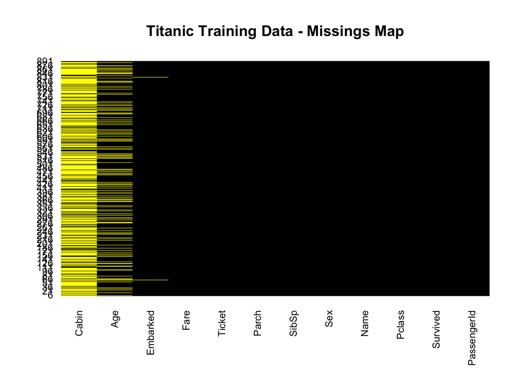

```r
# Find out how much missing data and choose predictors
missmap(train.raw, main="Titanic Training Data - Missings Map", col=c("yellow", "black"), legend=FALSE)
```

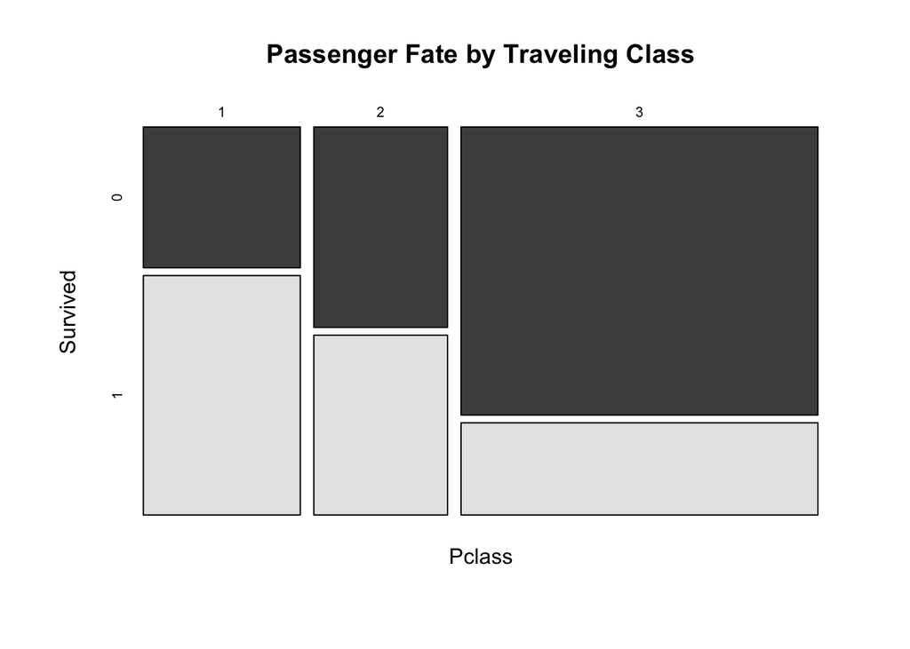

```r
# Understand what might influence the outcome
mosaicplot(train.clean$Pclass ~ train.clean$Survived, main="Passenger Fate by Traveling Class", shade=FALSE, color=TRUE, xlab="Pclass", ylab="Survived")
```

# Imputation of missing data

- Impute median age by title as imputeAge
- Impute Embarked by the most frequent value
- Impute suspicious or missing Fare by Pclass
- Group titles into higher level

```r
# Impute missing age using title
getTitle <- function(data) {
  #data <- train.raw
  #data$Name
  title.dot.start <- regexpr("\\,[A-Z ]{1,20}\\.", data$Name, TRUE)
  title.comma.end <- title.dot.start + attr(title.dot.start, "match.length")-1
  #data$Name[1]
  #title.dot.start[1]
  data$title <- substr(data$Name, title.dot.start+2, title.comma.end-1)
  data$title[which(data$title == "Ms")] <- 'Mrs'
  #data$title[which(data$title == "Mlle")] <- 'Mme'
  return (factor(data$title))
}

#Age, title, title.na
imputeMedian <- function(impute.var, filter.var, var.levels) {
  for (v in var.levels) {
    impute.var[which(filter.var == v)] <- impute(impute.var[which(filter.var == v)], what="median")
  }
  return (impute.var)
}

imputeAgeByTitle <- function(df){
  age.stat <- bystats(df$Age, df$title,fun=function(x)c(Mean=mean(x),Median=median(x)))
  title.na <- names(age.stat[age.stat[,"Missing"]>0,"N"])
  title.i <- which(title.na == "ALL")
  title.na <- title.na[-title.i]
  df$imputeAge <- imputeMedian(df$Age, df$title, title.na)
  return(df)
}

imputeEmbarked <- function(df){
  df$imputeEmbarked <- df$Embarked
  df$imputeEmbarked[which(is.na(df$imputeEmbarked))] <- 'S'
  return(df)
}

imputeFareByPclass <- function(df){
  df$Fare[ which( df$Fare == 0 )] <- NA
  df$Fare <- imputeMedian(df$Fare, df$Pclass, as.numeric(levels(df$Pclass)))
  return(df)
}

changeTitles <- function(df, old.titles, new.title) {
  for (old in old.titles) {
    df$newTitle[ which(df$newTitle == old)] <- new.title
  }
  return(df)
}

reassignTitle <- function(df){
  df$newTitle <- as.character(df$title)
  df <- changeTitles(df, c("Capt", "Col", "Don", "Dona", "Dr", "Jonkheer", "Lady", "Major", "Rev", "Sir"),"Noble")
  df <- changeTitles(df, c("the Countess", "Ms"),"Mrs")
  df <- changeTitles(df, c("Mlle", "Mme"),"Miss")
  df$newTitle <- factor(df$newTitle)
  return(df)
}


train.clean$title <- getTitle(train.clean)
table(train.clean$title)
```

```
##
##         Capt          Col          Don           Dr     Jonkheer
##            1            2            1            7            1
##         Lady        Major       Master         Miss         Mlle
##            1            2           40          182            2
##          Mme           Mr          Mrs          Rev          Sir
##            1          517          126            6            1
## the Countess
##            1
```

```r
train.clean <- reassignTitle(train.clean)
train.clean <- imputeAgeByTitle(train.clean)
train.clean[train.clean$title == "Dr",]
```

```
##     PassengerId Survived Pclass                          Name    Sex Age
## 246         246        0      1   Minahan, Dr. William Edward   male  44
## 318         318        0      2          Moraweck, Dr. Ernest   male  54
## 399         399        0      2              Pain, Dr. Alfred   male  23
## 633         633        1      1     Stahelin-Maeglin, Dr. Max   male  32
## 661         661        1      1 Frauenthal, Dr. Henry William   male  50
## 767         767        0      1     Brewe, Dr. Arthur Jackson   male  NA
## 797         797        1      1   Leader, Dr. Alice (Farnham) female  49
##     SibSp Parch   Ticket     Fare Cabin Embarked title newTitle imputeAge
## 246     2     0    19928  90.0000   C78        Q    Dr    Noble      44.0
## 318     0     0    29011  14.0000  <NA>        S    Dr    Noble      54.0
## 399     0     0   244278  10.5000  <NA>        S    Dr    Noble      23.0
## 633     0     0    13214  30.5000   B50        C    Dr    Noble      32.0
## 661     2     0 PC 17611 133.6500  <NA>        S    Dr    Noble      50.0
## 767     0     0   112379  39.6000  <NA>        C    Dr    Noble      46.5
## 797     0     0    17465  25.9292   D17        S    Dr    Noble      49.0
```

```r
train.clean <- imputeEmbarked(train.clean)
#Impute Fare if 0 / missing
train.clean <- imputeFareByPclass(train.clean)
#Explore relationship between title and survival
table(train.clean$title,train.clean$Survived)
```

```
##
##                  0   1
##   Capt           1   0
##   Col            1   1
##   Don            1   0
##   Dr             4   3
##   Jonkheer       1   0
##   Lady           0   1
##   Major          1   1
##   Master        17  23
##   Miss          55 127
##   Mlle           0   2
##   Mme            0   1
##   Mr           436  81
##   Mrs           26 100
##   Rev            6   0
##   Sir            0   1
##   the Countess   0   1
```

What does the data look like after cleaning

```r
summary(train.clean)
```

```
##   PassengerId    Survived Pclass      Name               Sex
##  Min.   :  1.0   0:549    1:216   Length:891         female:314
##  1st Qu.:223.5   1:342    2:184   Class :character   male  :577
##  Median :446.0            3:491   Mode  :character
##  Mean   :446.0
##  3rd Qu.:668.5
##  Max.   :891.0
##
##       Age            SibSp           Parch           Ticket
##  Min.   : 0.42   Min.   :0.000   Min.   :0.0000   Length:891
##  1st Qu.:20.12   1st Qu.:0.000   1st Qu.:0.0000   Class :character
##  Median :28.00   Median :0.000   Median :0.0000   Mode  :character
##  Mean   :29.70   Mean   :0.523   Mean   :0.3816
##  3rd Qu.:38.00   3rd Qu.:1.000   3rd Qu.:0.0000
##  Max.   :80.00   Max.   :8.000   Max.   :6.0000
##  NA's   :177
##       Fare            Cabin           Embarked       title
##  Min.   :  4.013   Length:891         C   :168   Mr     :517
##  1st Qu.:  7.925   Class :character   Q   : 77   Miss   :182
##  Median : 14.500   Mode  :character   S   :644   Mrs    :126
##  Mean   : 32.689                      NA's:  2   Master : 40
##  3rd Qu.: 31.275                                 Dr     :  7
##  Max.   :512.329                                 Rev    :  6
##                                                  (Other): 13
##    newTitle     imputeAge     imputeEmbarked
##  Master: 40   Min.   : 0.42   C:168
##  Miss  :185   1st Qu.:21.00   Q: 77
##  Mr    :517   Median :30.00   S:646
##  Mrs   :127   Mean   :29.39
##  Noble : 22   3rd Qu.:35.00
##               Max.   :80.00
##
```